# KTT (Status: okay, evtl. leicht überarbeiten)

von Mark Heckmann

```r
# Alle nötigen Pakete laden
library(CTT)
library(plyr)
library(ggplot2)
```

# Spearman-Brown Korrektur bei parallelen Tests

Die Spearman-Brown Formel erlaubt die Berechung der Änderung in der Reliabilität einer Messung, bei Verlängerung oder Verkürzung eines Tests. Im Folgenden gehen wir davon aus, dass der Summenscore $S$ aus $m$ separaten parallelen, d.h. $\tau-äquivalenten$ Testteilen $Y_i$ zusammengesetzt wird, d.h.

$$S = Y_1 + \dots + Y_m.$$

Somit ergibt sich für nach Spearman-Brown auf Basis der Reliabilität der Einzeltests $Rel(Y)$ die neue Realibilität für $S$ von

$$Rel(S) = \frac {m \cdot Rel(Y)}
{1 + (m-1)\cdot Rel(Y)}$$

Nehmen wir an wir bilden den Summenscore $S$ aus zwei parallelen Tests $Y_1$ und $Y_2$. Es handelt sich somit um eine Testlängenverdoppelung, d.h. $m=2$. Die Reliabilität verändert sich nach obiger Formel wie folgt. Zur Berechnung wird die Funktion `spearman.brown` aus dem Paket `CTT` genutzt.

```r
rel.new <- spearman.brown(0.9, 2, "n")   # aus Paket CTT
rel.new
```

```
## $r.new
## [1] 0.9473684
```

Bei einer Testverlängerung um den Faktor $2$ erhöht sich die Reliabilität von $0.9$ auf $Rel(S)=0.95$.

Fragen wir nun anders herum. Bei einer minimal akzeptablen Reliabilität von $0.9$, kann der Test mit einer aktuellen Reliabilität von $Rel(S)=0.947$ um welchen Faktor verkürzt werden?

```r
m.new <- spearman.brown(0.947, 0.9, "r")   # "r", da Reliabilität als input
m.new
```

```
## $n.new
## [1] 0.5036959
```

Wir erhalten genau das umgekehrte Ergebnis. Der Test kann in der Länge halbiert werden.

Im Folgenden konstruieren wir eine Tabelle, so wie sie in vielen Lehrbüchern vorkommt, aus der die eben berechneten Veränderung der Realibilität bei Testverlängerung oder -verkürzung optisch abgelesen werden können.

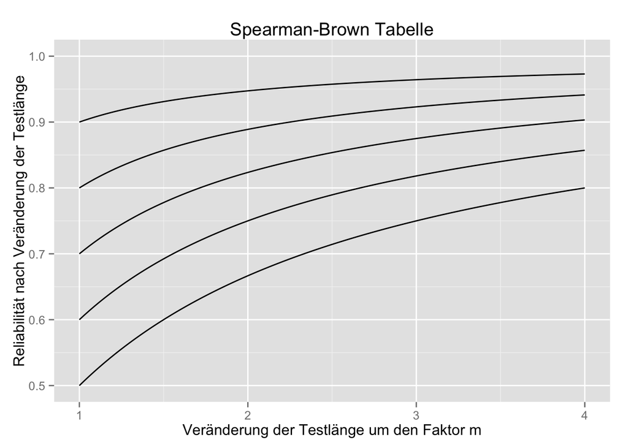

```r
m <- seq(1, 4, len=100)
rel <- seq(.5, .9, .1)
d <- expand.grid(m=m, rel=rel)
d$id <- 1:nrow(d)
d <- ddply(d, .(id), transform, rel.new = spearman.brown(rel, m))
g <- ggplot(d, aes(x=m, y=r.new, group=rel)) + geom_line() + ylim(.5, 1) +
        xlab("Veränderung der Testlänge um den Faktor m") +
        ylab("Reliabilität nach Veränderung der Testlänge") +
        ggtitle("Spearman-Brown Tabelle")
g
```

# Herleitung der Spearman-Brown Formel (bei parallelen Tests)

Die Variable $S$ sei die Summe von $m$ $\tau$-äquivalenten Variablen, d.h. $S= Y_1 + \dots + Y_m$. Somit ist die Reliabilität von $S$ definiert als

$$Rel(S) = \frac{Var(\tau_S)}{Var(S)}$$

Zur Herleitung der Spearman-Brown Formel schauen wir uns zunächst den Zähler des Ausdrucks an. hier taucht $Var(\tau_S)$ auf. Da $\tau_S$ die Regression der True-Score Variablen auf $U$ (Personenvariable) ist, erhalten wir

$$\tau_S := E(S|U) = E(Y_1 + \dots + Y_m|U) \\
E(Y_1|U) + \dots + E(Y_m|U) = \\
\tau_1 + \dots + \tau_m.$$

Somit ist $\tau_S = \tau_1 + \dots + \tau_m$ und folglich

$$Var(\tau_S) = Var(\tau_1 + \dots + \tau_m) = \\
\sum_i Var(\tau_i) + \underbrace{\sum_i \sum_j}_{i \neq j} Cov(\tau_i, \tau_j).$$

Wir erhalten für die $m$ Variablen folgende Varianz-Kovarianzmatrix

$$\begin{pmatrix}
Var(\tau_1) & \cdots & Cov(\tau_1, \tau_m) \\
\vdots & \ddots & \vdots \\
Cov(\tau_m, \tau_1) & \cdots & Var(\tau_m) \\
\end{pmatrix}.$$

Da $\tau_i = \tau_j$ und somit $Cov(\tau_i, \tau_j) = Var(\tau)$ erhalten wir in der gesamten Varianz-Kovarianzmatrix identische Einträge, d.h.

$$\begin{pmatrix}
Var(\tau) & \cdots & Var(\tau) \\
\vdots & \ddots & \vdots \\
Var(\tau) & \cdots & Var(\tau) \\
\end{pmatrix}.$$

Die Varianz von $\tau_S$ ist die Summe aller Elemente der Matrix (siehe Abschnitt *Rechnen mit Varianzen*), d.h.

$$Var(\tau_S) = m^2 \cdot Var(\tau)$$

Betrachten wir nun die Varianz der Summenvariable $S$ im Nenner, d.h.

$$Var(S) = Var(Y_1 + \dots + Y_m) = \\
\sum_{i=1}^m{Var(Y_i)} + \underbrace{\sum_{i=1}^m \sum_{j=1}^m}_{i \neq j} Cov(Y_i, Y_j)$$

Die Varianzen der Variablen parallerer Tests $Y_i$ sind alle gleich, da für alle gilt $Var(Y) = Var(\tau) + Var(\epsilon)$. Weiterhin ist $Cov(Y_i, Y_j) = Cov(\tau + \epsilon_i, \tau + \epsilon_j) = Var(\tau)$. Somit erhalten wird

$$m \cdot Var(Y) + m \cdot (m-1) \cdot Var(\tau)$$

Wir erhalten somit für die Reliabilität

$$Rel(S) = \frac{Var(\tau_S)}{Var(S)} \\
= \frac{m^2 \cdot Var(\tau)}
{m \cdot Var(Y) + m \cdot (m-1) \cdot Var(\tau)} \\
= \frac{m \cdot Var(\tau)}
{Var(Y) + (m-1) \cdot Var(\tau)}$$

Erweitern mit $Var(Y)$ ergibt

$$= \frac{m \cdot Var(\tau) / Var(Y) }
{Var(Y) / Var(Y) + (m-1) \cdot Var(\tau) / Var(Y)}$$

Da $Rel(Y) = \frac{Var(\tau)}{Var(Y)}$ erhalten wir

$$= \frac{m \cdot Rel(Y) }
{1 + (m-1) \cdot Rel(Y)}.$$

# Anhang: Rechnen mit Varianzen

$S$ sei die Summe von $m$ Variablen, d.h. $S = Y_1 + \dots + Y_m$. $Var(S)$ ist dann die Summe aller Einträge aus der zugehörigen Varianz-Kovarianzmatrix. Für den Fall von drei Variablen, d.h. $S = Y_1 + Y_2 + Y_3$ erhalten wir die Varianz-Kovarianzmatrix

$$\begin{pmatrix}
Var(Y_1) & Cov(Y_1, Y_2) & Cov(Y_1, Y_3) \\
Cov(Y_1, Y_2) & Var(Y_2) & Cov(Y_2, Y_3) \\
Cov(Y_1, Y_3) & Cov(Y_2, Y_3) & Var(Y_3) \\
\end{pmatrix}.$$

Durch Aufaddieren aller Einträge erhalten wir

$$Var(Y_1 + Y_2 + Y_3) = \sum_i Var(Y_i) + \underbrace{\sum_i \sum_j}_{i \neq j} Cov(Y_i, Y_j).$$

Die Formeln in R überprüfen:

```r
set.seed(0)
d <- replicate(3, rnorm(10))      # Drei Variablen mit zufälligen Werten erzeugen
d <- as.data.frame(d)             # in Dataframe umwandeln
vc <- cov(d)                      # Varianz-Kovarianzmatrix
vc
```

```
##            V1          V2          V3
## V1  1.4528358 -0.20093966 -0.10432388
## V2 -0.2009397  0.46086672 -0.05828058
## V3 -0.1043239 -0.05828058  0.48606879
```

```r
sum(vc)                           # Alle Einträge der Matrix addieren
```

```
## [1] 1.672683
```

```r
d <- transform(d, S = V1+V2+V3)   # Summenvariable S bilden
var(d$S)                          # Varianz ist identisch mit obiger Berechnung
```

```
## [1] 1.672683
```